# Age structured model to track cell-age and ki67 exprerssion in naive T cells

11 March, 2020

## PDE Model

In order to track the dynamics of cells of age ‘a’ expressing the nuclear protein Ki67 with an intensity ‘k’ through time `t’, we use the following PDE,
$$\begin{equation}
\frac{\partial u}{\partial t} +\frac{\partial u}{\partial a} - \beta \, k \, \frac{\partial u}{\partial k} = - \delta(a) \, u.
\label{eq:PDE}
\end{equation}$$
- $\beta$ is the rate of loss of Ki67 expression, and
- $\delta$ is the rate with which cells are lost from the population either by death or by differentiation. We assume that it varies with cell-age.

To minimise the experimental variation we normalise the intensity of Ki67 such that $k$ $\in (0, 1)$. The Ki67 intensity is highest ($k=1$) when cells enter division and then decays exponentially with rate constant $\beta$. The threshold Ki67 intensity $\bar{k}$ identifies the cells that are gated as Ki67$^{+}$ in experimental observations (k $\ge$ $\bar{k}$).

To solve this linear first-order PDE (eq.), we need to transform it into an ODE such as,
$$\begin{equation}
\frac{d}{ds}u(t(s), a(s), k(s)) = F(u, t(s), a(s), k(s)),
\label{eq:ODE}
\end{equation}$$
along the characteristic curve (t(s), a(s), k(s)).

The solution of the ODE (eq.~) is given by,
$$\begin{eqnarray}
\begin{aligned}
&\frac{du}{ds} = - \delta(a) \, u, \\
&\text{which can be solved to give,} \\
&u(s) = u_0 \, exp(- \int \delta(s) ds).
\end{aligned}
\label{eq:SOL}
\end{eqnarray}$$
Therefore, if we know $u(t_0, a_0, k_0) \equiv \, u_0$ we can find $u(t(s), a(s), k(s)$ using eq. , since (t(s), a(s), k(s)) and (t(0), a(0), k(0)) both lie on the same characteristic curve.

We track the folllowing three cohorts of naive T cells that form the boundary conditions for the PDE in eq. alomg this charcteristic curve.  
- Initial population present at $t_0 \Rightarrow u_\text{init} = u(t=0, a, k)$,  
- Cells coming from the source $\Rightarrow u_\text{source} = u(t, a=0, k)$ and  
- Cells that entered division $\Rightarrow u_\text{div} = u(t, a, k=1)$.

**Total size of the population at `time t`** is derived by integrating the sum of cell densities of these three cohorts over all allowable cell ages and Ki67 intensities.
$$\begin{equation}
u(t) = \int_{a = 0}^t \int_{k = 0}^1 u_\text{init} + u_\text{source} + u_\text{div} \, \, dk \, \, da
\end{equation}$$

**The proportions of Ki67$^{+}$ cells within the naive compartment at `time t`** is estimated by integrating the sum of cell densities of the three cohorts from the threshold Ki67 intensity $\bar{k}$ to 1 and over all allowable cell ages.
$$\begin{equation}
\kappa(t) = \frac{ \int_{a = 0}^t \int_{k = \bar{k}}^1 u_\text{init} + u_\text{source} + u_\text{div} \, \, dk \, \, da.}{u(t)}
\end{equation}$$

## Thymic export

Mature CD4 SP cells migrate to the respective peripheral naive compartments continuously. The numbers of new naive T cells exported to the peripheral lymphoid organs varies across the mouse life-span, due to the changes in the SP population sizes owing to thymic involution. Moreover, the proportion of Ki67$^{+}$ cells within the thymic SP CD4 compartment changes with host-age. In order to characterise the influx of Ki67$^{+}$ and Ki67$^{-}$ thymic emigrants into the peripheral naive compartments we define phenomenological function to track the counts and fraction of Ki67$^{+}$ cells within the thymic SP CD4 subset.

#### Dynamics of Ki67 expression within the thymic CD4 SP subsest

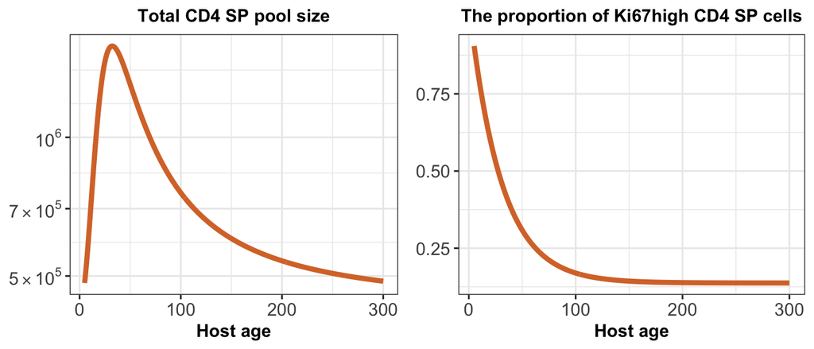

```r
# the function for thymic SP population -- changes with time
theta_t <- function(dpt){

  ## parameters estimated from spline fit to the timecourse of counts of source compartment -- SP
  if (Population == "CD4") {
    spline_est_list <- list("theta_0"  = 4.3e5, 'theta_f' = 1.8e3, "n" = 2.1, "X" = 30, "q" = 3.7)
  } else if (Population == "CD8") {
    spline_est_list <- list("theta_0"  = 9e4, 'theta_f' = 68, "n" = 3, "X" = 25, "q" = 4.25)
  }

  ## days post t_0 -- dpt

  ## change in SP counts with time
  theta = spline_est_list$theta_0 + (spline_est_list$theta_f * dpt^spline_est_list$n) *
    (1 - ((dpt^spline_est_list$q)/((spline_est_list$X^spline_est_list$q) + (dpt^spline_est_list$q))))


  return(theta)
}

# function for ki67 proportions in thymic output -- changes with time
eps_func <- function(Time){
  ## spline fitted separately to the proportions of ki67+ cells within thymic SP4 cells
  ## parameters estimated from spline fit to the timecourse of ki67 proportions within the source compartment -- SP
  if (Population == "CD4") {
    spline_est_list <- list("eps_0"  = 0.13732103, 'eps_f' = 0.03337899, "A" = 2.92554110)
  } else if (Population == "CD8") {
    spline_est_list <- list("eps_0"  = 0.24510453, 'eps_f' = 0.01559996, "A" = 14.83715328)
  }

  eps = exp(-spline_est_list$eps_f * (Time + spline_est_list$A)) + spline_est_list$eps_0

  return(eps)
}

p1 <- ggplot()+
  geom_line(aes(ts_pred, theta_t(ts_pred)), size =1.5, col = "#D87534") +
  labs(x = 'Host age', y = NULL, title = paste0("Total ", Population , " SP pool size")) +
  scale_y_log10(labels = fancy_scientific) + myTheme

p2 <- ggplot()+
  geom_line(aes(ts_pred, eps_func(ts_pred)), size =1.5, col = "#D87534") +
  labs(x = 'Host age', y = NULL, title = paste0("The proportion of Ki67high ", Population, " SP cells")) + myTheme

gridExtra::grid.arrange(p1, p2, nrow = 1)
```

#### Daily influx from thymic CD4 SP subset

We assume that the proportion of CD4 SP T cells entering naive pool daily, defined as $\psi$, remains constant throughout the mouse life. We also consider that both the Ki67$^{+}$ and Ki67$^{-}$ SP cells follow the same kinetics of migration.

Therefore, the number of cells entering the total, Ki67$^{+}$ and Ki67$^{-}$ naive T cell subsets are given by,
$$\begin{eqnarray}
\begin{aligned}
&\phi(t) = \psi \, \theta(t), \\
&\phi^{+}(t) = \psi \, \theta(t) \, \epsilon(t) \, \text{ and} \\
&\phi^{-}(t) = \psi \, \theta(t) \, (1 - \epsilon(t)) \, \text{, respectively. }
\end{aligned}
\label{eq:Source_influx}
\end{eqnarray}$$

#### The distribution of Ki67 intensities within the thymic export

In our system, we define $\bar{k}$ as the thresold Ki67 intensity used to gate as Ki67$^{+}$ cells. We assume that the intensity of ki67 drops with a constant rate $\beta$ with time $k = e^{\beta \, t}$ (for normalised k, where $k_0 = 1$). Therefore, at time $= \frac{1}{\beta} \rightarrow k = \bar{k} \text{ and } \rightarrow \bar{k} = \frac{1}{e}$.

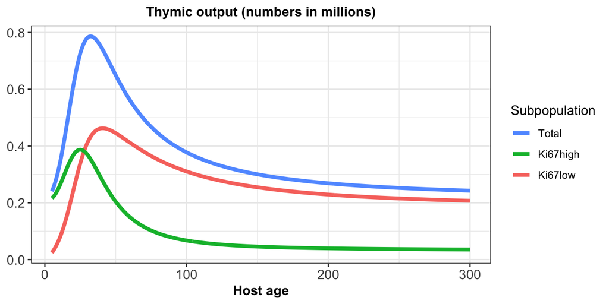

```r
## the function for thymic influx into the naive T cell compartment
phi_t <- function(Time, parms) {
  N0 = parms[1]
  #q1 = parms[2]

  t0 = 5

  ## psi is the proportion of SP cells that enter naive pool daily -- constant here
  #psi = (exp(N0) * q1)/(theta_t(t_0) * (exp(q1 * t_0) - 1))
  ### simpler assumption is that intital age and ki67 distribution is same as the thymic output -- because t0 = 5 days.
  ### g(a, k) = phi(t0, k) --> integral of g(a, k) across 0 to t0 == 5 * phi_0 == 5 * theta_0 * psi.
  ### therefore psi = N0/(5 * theta_0)  --- this wouldnt hold if t0 was even slightly larger.
  psi = exp(N0)/(5 * theta_t(t0))

  value = ifelse(Time >= t0, psi * theta_t(Time),
                 0)

  ## the proportional influx at each time 't' is,
  return(value)
}


# distribution of ki67 expression in thymic output -- changes with time
k_dist <- function(ki, Time){

  k_bar = 1/exp(1)
  n = 60
  t_0 = 5

  value = (eps_func(Time)/(1 - k_bar)) +
    ((((1 - eps_func(Time))/(k_bar)) - (eps_func(Time)/(1 - k_bar)))/(1 + (ki/k_bar)^n))

  return(value)
}


## function to give ki67 distribution of thymic output at a given time 't' -- change with time.
phi_k_t <- function(ki, Time, parms){
  t0 = 5
  value = phi_t(Time, parms) *
    k_dist(ki, Time)

  return(value)
}

## integrating phi_k_t from 0 to 1 gives total thymic output
# from k_bar (threshold for ki67+ signal) to 1 gives the total numbers of ki67+ cells in the thymic output
phi_int <- function(Time, parms, low_lim_kbar){
   value <- function(Time, parms, low_lim_kbar) {
     k_bar = 1/exp(1)

     low_lim = ifelse(low_lim_kbar == FALSE, 0,
                      k_bar)

    return(integrate(phi_k_t, lower = low_lim, upper = 1, Time=Time, parms=parms)$value)
   }

  return(mapply(value, Time, MoreArgs = list(parms, low_lim_kbar)))
}

phi_df <- data.frame("Time" = ts_pred,
                     "Total" = phi_int(ts_pred, start_vec, F),
                     "Ki_pos" = phi_int(ts_pred, start_vec, T)) %>%
  mutate(Ki_neg = Total - Ki_pos) %>%
  gather(-Time, key = Subpopulation, value = Counts)

ggplot(phi_df) +
  geom_line(aes(Time, Counts/1e6, col = Subpopulation), size =1.5) +
  #scale_y_log10(labels = fancy_scientific) +
  scale_color_discrete(breaks = c("Total", "Ki_pos", "Ki_neg"),
    labels = c( "Total", "Ki_pos" = "Ki67high", "Ki_neg" = "Ki67low")) +
  labs(x = 'Host age', y = NULL, title = "Thymic output (numbers in millions)") + myTheme
```

## Tracking the cohorts of cells of age ‘a’ and Ki67 intensity ‘k’

### The initial population

We define the distribution of cell-ages and ki67 intensities of naive T cells pre-existing at `time t0` using a function $g(a, k)$.
$$\begin{equation}
u_\text{init}(t, a, k) = g(a, k).
\end{equation}$$

The total size of this initial population is given by the integral of their age and ki67 distribution across all possible values of cell ages (0 to $t_0$) and ki67 intensities (0 to 1). Similarly, the proportion of Ki67$^{+}$ cells at time $t_0$ is given by dividing the integral of $g(a, k)$ across all ages and from $\bar{k}$ to 1 with the total pool size $N_0$.
$$\begin{eqnarray}
N_0 = \int_0^{t_0} \int_0^1 g(a, k) \, dk \, da \\
\kappa_0 = \frac{\int_0^{t_0} \int_{\bar{k}}^1 g(a, k) \, dk \, da}{N_0}
\end{eqnarray}$$

The initial population of naive T cells includes the cohort of thymic emigrants that entered the periphery at $t_0, \, \rightarrow g(0, k) = \phi(t_0, k).$ Since, the earliest time-point of experimental observations is day 5 since birth, we assume that the effects of cell-age on naive T cells dynamics would be extremely small and therefore, consider that the $g(a, k)$ is uniform and more or less reflects the distributions in the thymic output *i.e.,* $\phi(t_0, k)$.

**Expressing the rate of daily thymic influx in terms of pool size of initial population – $N_0$.**

$$\begin{eqnarray}
\begin{aligned}
&N_0 = \int_{s=0}^{t_0} g(s) \, ds
\quad = \int_{s=0}^{t_0} \phi(t_0) \, ds
\quad = \psi \, \theta(t_0) \, t_0 \\
&\therefore \psi = \frac{N_0}{t_0 \, \theta(t_0)}.
\end{aligned}
\end{eqnarray}$$

```r
## tracking preexisting cells that were present at t0
## the age distribution of cells presnt at t0
g_age <- function(age, parms){
  q1 = 0 # parms[2]  ## We asssumed it to be flat since t0 is very small.
  #### simpler assumption that age and ki67 distr. are flat because t0 is very small
  t_0 = 5

  # g(a)
  value = ifelse(age >= 0,
                 phi_t(t_0, parms) * exp(q1 * age),
                 0)

  return(value)
}

## the age and ki67 distribution of cells presnt at t0
g_k_a <- function(ki, age, Time, parms){

  # g(a, k)
  value = g_age(age, parms) * k_dist(ki, Time)    ### proportional reduction in cells of age 'a' and ki67 'k'

  return(value)
}
```

Along the charcteristic curve $(a(s), t(s), k(s))$ the PDE is reduced to an ODE. By solving the charactristics system of ODEs the we determine the solution along the first boundary condition *i.e.* the initial population as follows.
$$\begin{eqnarray}
\begin{aligned}
&\frac{dt}{ds} = 1 \quad \rightarrow t = s + t_0 \quad \rightarrow t_0 = 0 \quad \rightarrow s = t \\
&\frac{da}{ds} = 1 \quad \rightarrow a = s + a_0 \quad \rightarrow a_0 = a - t \\
&\frac{dk}{ds} = -\beta \, k \quad \rightarrow k = k_0 \, e^{-\beta \, s} \quad \rightarrow k_0 = k \, e^{\beta \, t}.
\end{aligned}
\end{eqnarray}$$
Therefore,
$$\begin{equation}
u_\text{init}(0, a_0, k_0) = \phi(0, k \, e^{\beta \, t}).
\end{equation}$$

**Cellular Turnover:** We assumed that the rate wth which cells are lost either by death or differentiation *i.e.,* ‘$\delta$’ changes exponentially with their age,
$$\begin{equation}
\delta (a) = \delta_0 \, e^{-r \, a}.
\end{equation}$$

```r
### cellular turnover changing with cellage
delta_age <- function(age, parms){
  delta0 = parms[2]
  r_del = parms[3]

  return(delta0 * exp(-r_del * age))
}

delta_integ <- function(lo_lim, up_lim, parms){

  delta_value <- function(lo_lim, up_lim, parms){
    integrate(delta_age, lower = lo_lim, upper = up_lim, parms=parms)$value
  }

  ## mapply return the out put of the value function across each elements of vectors
  ## lower and upper for the same values of params as a list
  return( mapply(delta_value, lo_lim, up_lim, MoreArgs = list(parms)))
}
```

Using $u_{p}(t_0, a_0, k_0)$ and $\delta(a)$ the initial population can be tracked on the characteristic curve `$S$’,
$$\begin{equation}
\begin{aligned}
u_\text{init}(t, a, k) &= u_\text{init}(0, a_0, k_0) \, exp\big(- \int_{a-t}^{a} \delta(\tau) \; d\tau \big)\\
&= \phi\big(0, k \, e^{\beta \, t}\big) \, exp\big(- \int_{a-t}^{a} \delta(\tau) \; d\tau \big)
\end{aligned}
\end{equation}$$

The distribution of ki67 expression of cells within the initial popualtion at `time t` is,
$$\begin{equation}
u_\text{init}(t, k) = \int_0^t \phi\big(0, k \, e^{\beta \, t}\big) \, exp\big(- \int_0^{t} \delta(\tau + a - t) \; d\tau\big) \; da.
\end{equation}$$

Therefore the total size ($N_\text{p}$) of the ‘Pre-existing cohort’ and the porportion of Ki67$^+$ cells ($\kappa_\text{p}$) within it are given by,
$$\begin{eqnarray}
\begin{aligned}
& N_\text{init}(t) = \int_0^1 u_\text{p}(t, k) \; dk \\
& \kappa_\text{init}(t) = \frac{\int_{\bar{k}}^1 u_\text{p}(t, k) \, dk }{N_\text{p}(t)}.
\end{aligned}
\end{eqnarray}$$

```r
### pre-existing cells age and ki67 distribution
N_init_k_a <- function(age, ki, Time, parms){
  delta0_log = parms[2]   ### log transforming parameter ---> delta0 > 0
  delta0 = exp(delta0_log)

  r_del  = parms[3]       ### free parameter

  t0 = 5

  #value = g_k_a(ki, age,Time, parms) * exp(- delta_integ(lo_lim = 0, up_lim = age, parms))
  ### analytically solved inetgral for delta_age to speed up the estimation
  value = g_k_a(ki, age - Time + t0, Time, parms) * exp(- (delta0/r_del) * (exp(-r_del * (age - Time + t0))
                                                                            - exp(-r_del * age)))

  return(value)
}

## ki67 distribution of the cohorts entered from the thymus post 't0'
## integral across all possible ages
N_init_k <- function(ki, Time, parms){

  init_value <- function(ki, Time, parms){
    t0 = 5
    return(integrate(N_init_k_a, lower = Time - t0, upper = Time, ki=ki, Time=Time, parms = parms)$value)
  }
  ## mapply return the out put of the value function across each elements of vectors
  ## k and t for the same values of params as a list
  return(mapply(init_value, ki, Time, MoreArgs = list(parms)))
}


## number of ki67+ cells within the cohorts entered from the thymus post 't0' at time 't'
k_init <- function(Time, parms){

  k_value <- function(Time, parms){
    k_bar = 1/exp(1)

    ## inetgrating across k_bar to 1
    return(integrate(N_init_k, lower = k_bar, upper = 1, Time=Time, parms=parms)$value)
  }
  ## mapply return the out put of the value function across each elements of vector
  ## t for the same values of params as a list
  return(mapply(k_value, Time, MoreArgs = list(parms)))
}

## total population size of the cohorts entered from the thymus post 't0' at time 't'
N_init <- function(Time, parms){

  init_value <- function(Time, parms){

    ## inetgrating across all k values
    return(integrate(N_init_k, lower = 0, upper = 1, Time=Time, parms=parms)$value)
  }
  ## mapply return the out put of the value function across each elements of vector
  ##t for the same values of params as a list
  return(mapply(init_value, Time, MoreArgs = list(parms)))
}

## proportions of ki67+ cells within the cohorts entered from the thymus post 't0' at time 't'
ki_prop_init <- function(Time, parms){

  # numbe rof ki67+ cells/ totla population size
  value =
    k_init(Time, parms)/
    N_init(Time, parms)

  return(value)
}
```

```r
# integration
time_integ_init <- paste0("time taken for integration -- ",
                           system.time(
                             c(counts_init_vec <- mcmapply(N_init, ts_pred, MoreArgs =list(start_vec), mc.cores = num_cores),
                               ki_prop_init_vec <- mcmapply(ki_prop_init, ts_pred, MoreArgs =list(start_vec), mc.cores = num_cores)),
                             gcFirst = TRUE)[3]
)

init_res_df <- data.frame("time" = ts_pred,
                           "Counts" = counts_init_vec,
                           "Ki67high proportions" = ki_prop_init_vec) %>%
  gather(-time, key = "features", value = "results")

ggplot()+
  geom_line(data = init_res_df, aes(time, results), col = "#D87534",  size = 1.5) +
  labs(title = paste0("Initial cohort - naive ", Population, " T cells"), x = "Host age (days)", y = NULL) +
  facet_wrap( .~ features, scales = "free") + myTheme

print(time_integ_init)
```

[output not shown]

### Cells coming from the source

We assume that cells of `age 0` constantly enter the target population from the source compartment which sets the second boundary condition for the PDE in eq. ,
$$\begin{equation*}
u_\text{source}(t, a=0, k) = \phi(t, k).
\end{equation*}$$
The characteristics system of ODEs for this boundary cod=ndition is,
$$\begin{eqnarray}
\begin{aligned}
&\frac{da}{ds} = 1 \quad \rightarrow a = s + a_0 \quad \rightarrow a_0 = 0 \quad \rightarrow s = a \\
&\frac{dt}{ds} = 1 \quad \rightarrow t = s + t_0 \quad \rightarrow t_0 = t - a \\
&\frac{dk}{ds} = -\beta \, k \quad \rightarrow k = k_0 \, e^{-\beta \, s} \quad \rightarrow k_0 = k \, e^{\beta \, a}.
\end{aligned}
\end{eqnarray}$$
Therefore,
$$\begin{equation}
u_\text{source}(t_0, 0, k_0) = \phi(t_0, k_0)= \phi\big(t-a, k \, e^{\beta \, a}\big).
\end{equation}$$

Using $\phi(t_0,k_0)$ and $\delta(a)$ the cohort of cells (age = 0) entering from the source can be tracked across `time t`,
$$\begin{equation}
\begin{aligned}
u_\text{source}(t, a, k) &= u_\text{source}(t_0, 0, k_0) \, exp\big(- \int_0^a \delta(\tau) \; d\tau \big)\\
&= \phi\big(t-a, k \, e^{\beta \, a}\big) \, exp\big(- \int_0^a \delta(\tau) \; d\tau \big)
\end{aligned}
\end{equation}$$
The distribution of ki67 expression of the cohorts entered from the thymus post ‘$t_0$’ at `time t` is,
$$\begin{equation}
u_\text{source}(t, k) = \int_0^t \phi\big(t-a, k \, e^{\beta \, a}\big) \, exp\big(- \int_0^a \delta(\tau) \; d\tau\big) \; da.
\end{equation}$$

Therefore the total size ($N_\text{source}$) of the cohort of cells derived from the source compartment and the porportion of Ki67$^+$ cells ($\kappa_\text{source}$) within them are given by,
$$\begin{eqnarray}
\begin{aligned}
& N_\text{source}(t) = \int_0^1 u_\text{s}(t, k) \; dk \\
& \kappa_\text{source}(t) = \frac{\int_{\bar{k}}^1 u_\text{s}(t, k) \, dk }{N_\text{s}(t)}.
\end{aligned}
\end{eqnarray}$$

```r
### cells coming from source -- age 0
N_theta_k_a <- function(age, ki, Time, parms){
  delta0_log = parms[2]   ### log transforming parameter ---> delta0 > 0
  delta0 = exp(delta0_log)

  r_del  = parms[3]       ### free parameter

  t0 = 5

  #value = phi_k_t(ki * exp(beta * age), Time - age, parms) * exp(- delta_integ(lo_lim = 0, up_lim = age, parms))
  ### analytically solved inetgral for delta_age to speed up the estimation
  value = phi_k_t(ki * exp(beta * age), Time - age, parms) * exp(- (delta0/r_del) * (1 - exp(- r_del * age)))

  return(value)
}


## ki67 distribution of the cohorts entered from the thymus post 't0'
N_theta_k <- function(ki, Time, parms){

  theta_value <- function(ki, Time, parms){
    t0 =5

    return(integrate(N_theta_k_a, lower = 0, upper = Time - t0, ki=ki, Time=Time, parms = parms)$value)
  }
  ## mapply return the out put of the value function across each elements of vectors
  ## k and t for the same values of params as a list
  return(mapply(theta_value, ki, Time, MoreArgs = list(parms)))
}


## number of ki67+ cells within the cohorts entered from the thymus post 't0' at time 't'
k_theta <- function(Time, parms){

  k_value <- function(Time, parms){
    k_bar = 1/exp(1)

    ## inetgrating across k_bar to 1
    return(integrate(N_theta_k, lower = k_bar, upper = 1, Time=Time, parms=parms)$value)
  }
  ## mapply return the out put of the value function across each elements of vector
  ## t for the same values of params as a list
  return(mapply(k_value, Time, MoreArgs = list(parms)))
}

## total population size of the cohorts entered from the thymus post 't0' at time 't'
N_theta <- function(Time, parms){

  theta_value <- function(Time, parms){

    ## inetgrating across all k values
    return(integrate(N_theta_k, lower = 0, upper = 1, Time=Time, parms=parms)$value)
  }
  ## mapply return the out put of the value function across each elements of vector
  ##t for the same values of params as a list
  return(mapply(theta_value, Time, MoreArgs = list(parms)))
}

## proportions of ki67+ cells within the cohorts entered from the thymus post 't0' at time 't'
ki_prop_theta <- function(Time, parms){

  # numbe rof ki67+ cells/ totla population size
  value =
    k_theta(Time, parms)/
    N_theta(Time, parms)

  return(value)
}
```

```r
#Note that the `echo = FALSE` parameter was added to the code chunk to prevent printing of the R code that generated the plot.
# integration
time_integ_source <- paste0("time taken for integration -- ",
                           system.time(
                             c(counts_theta_vec <- mcmapply(N_theta, ts_pred, MoreArgs =list(start_vec), mc.cores = num_cores),
                               ki_prop_theta_vec <- mcmapply(ki_prop_theta, ts_pred, MoreArgs =list(start_vec), mc.cores = num_cores)),
                             gcFirst = TRUE)[3]
)


theta_res_df <- data.frame("time" = ts_pred,
                           "Counts" = counts_theta_vec,
                           "Ki67high proportions" = ki_prop_theta_vec) %>%
  gather(-time, key = "features", value = "results")

ggplot()+
  geom_line(data = theta_res_df, aes(time, results), col = "#D87534",  size = 1.5) +
  labs(title = paste0("Source cohort - naive ", Population, " T cells"), x = "Host age (days)", y = NULL) +
  facet_wrap( .~ features, scales = "free") + myTheme

print(time_integ_source)
```

[output not shown]

### Cells that entered division

We assume that cells enter division with a rate $\rho(a)$, depending on their age and then acquire the maximun ki67 intesity $k = k_\text{max} = 1$, since $k$ is the nomalised Ki67 intesity.

We also account for the delay-time that the cells that just entered division require before they renter the cell-cycle, by allowing cell division only in cells below a limiting $k$ intensity $k_\text{dL}$. The division limit *i.e.* $k_\text{dL}$ lies between the thresold Ki67$^{+}$ gating intensity and $k_\text{max}$, such that $k_\text{dL} \in (\bar{k}, 1)$.

Therefore the last boundary condition for the PDE in eq. ,
$$\begin{equation}
u_\text{div}(t, a, k_\text{max} = 1) = \rho(a) \, u(t, a, k) dk, \quad \text{where } k \in (0, k_\text{dL})
\end{equation}$$

The system of ODEs for this charcteristic curve is,
$$\begin{eqnarray}
\begin{aligned}
&\frac{dk}{ds} = -\beta \, k \quad \rightarrow k = k_0 \, e^{-\beta \, s} \quad \rightarrow k_0 =1 \quad \rightarrow s = \frac{-log(k)}{\beta} \\
&\frac{da}{ds} = 1 \quad \rightarrow a = s + a_0 \quad \rightarrow a_0 = a + \frac{log(k)}{\beta} \\
&\frac{dt}{ds} = 1 \quad \rightarrow t = s + t_0 \quad \rightarrow t_0 = t + \frac{log(k)}{\beta}
\end{aligned}
\end{eqnarray}$$

Using $u_\text{div}(t_0, a_0, k_0), \, \rho(a)$ and $\delta(a)$ the cohort of recently divided cells can be tracked on the characteristic curve `$S$‘,
$$\begin{equation}
u_\text{div}(t, a, k) = \rho(a) \, u(t + \frac{log(k)}{\beta}, a + \frac{log(k)}{\beta}, k) \, exp\big(- \int_{a + \frac{log(k)}{\beta}}^a \delta(\tau) \, d\tau \big)
\end{equation}$$
The distribution of ki67 expression within the cohort of cells that enetered division is,
$$\begin{equation}
u_\text{div}(t, k) = \int_0^t \rho(a) \, u(t + \frac{log(k)}{\beta}, a + \frac{log(k)}{\beta}, k) \, exp\big(- \int_{a + \frac{log(k)}{\beta}}^a \delta(\tau) \, d\tau \big) \, da.
\end{equation}$$
Therefore the total size ($N_\text{d}$) of the ’Division cohort’ and the porportion of Ki67$^+$ cells ($\kappa_\text{d}$) within it are given by,
$$\begin{eqnarray}
\begin{aligned}
& N_\text{div}(t) = \int_0^1 u_\text{d}(t, k) \; dk \\
& \kappa_\text{div}(t) = \frac{\int_{\bar{k}}^1 u_\text{d}(t, k) \, dk }{N_\text{d}(t)}.
\end{aligned}
\end{eqnarray}$$

```r
## tracking cells that entered division
## age and ki67 distribution of the pool of cells that can enter division
N_pool_k_a <- function(age, ki, Time, parms){

  ## combined age and ki distribution of theta and init cohorts
  value = N_theta_k_a(age, ki, Time, parms) + N_init_k_a(age, ki, Time, parms)

  return(value)
}

### cellular division changing with cellage
rho_age <- function(age, parms){
  rho0_log = parms[4]   ### log transforming parameter ---> delta0 > 0
  rho0 = exp(rho0_log)

  r_rho  = parms[5]       ### free parameter

  t0 = 5


  return(rho0 * exp(-r_rho * age))
}

### recently divided cells k=1
N_rdiv_k_a <- function(age, ki, Time, parms){
  delta0_log = parms[2]   ### log transforming parameter ---> delta0 > 0
  delta0 = exp(delta0_log)

  r_del  = parms[3]       ### free parameter

  t0 = 5
  k_dl = 0.6

  ### pooled cells
  u_pool_t0 <- function(ki, age , Time, parms){
    rho0_log = parms[4]   ### log transforming parameter ---> delta0 > 0
    rho0 = exp(rho0_log)

    rho0 * (N_init_a_k(ki, age + log(ki)/beta, Time + log(ki)/beta, parms) +
              N_theta_a_k(ki, age + log(ki)/beta, Time + log(ki)/beta, parms))
  }

  N_rdiv_t0 <- function(age, ki, Time, parms){
    delta0_log = parms[2]   ### log transforming parameter ---> delta0 > 0
    delta0 = exp(delta0_log)

    r_del  = parms[3]       ### free parameter

    t0 = 5
    k_dl = 0.6

    ifelse(ki <= k_dl,
           u_pool_t0(ki, age, Time, parms) *
             exp(- (delta0/r_del) * (exp(-r_del * (age + log(ki)/beta)) - exp(-r_del * age))),
           0)
  }

  u_pool_t <- function(ki, age , Time, parms){
    rho0_log = parms[4]   ### log transforming parameter ---> delta0 > 0
    rho0 = exp(rho0_log)

    rho0 * (N_init_a_k(ki, age + log(ki)/beta, Time + log(ki)/beta, parms) +
              N_theta_a_k(ki, age + log(ki)/beta, Time + log(ki)/beta, parms)+
              N_rdiv_t0(age, ki, Time, parms))
  }

  N_rdiv_t <- function(age, ki, Time, parms){
    delta0_log = parms[2]   ### log transforming parameter ---> delta0 > 0
    delta0 = exp(delta0_log)

    r_del  = parms[3]       ### free parameter

    t0 = 5
    k_dl = 0.6

    ifelse(ki <= k_dl,
           u_pool_t(ki, age, Time, parms) *
             exp(- (delta0/r_del) * (exp(-r_del * (age + log(ki)/beta)) - exp(-r_del * age))),
           0)

   # u_div_t(age, Time, parms) *
      #exp(- (delta0/r_del) * (exp(-r_del * (age + log(ki)/beta)) - exp(-r_del * age)))
  }

  func_value <- function(age, ki, Time, Parms){

    if(Time < t0 - (log(k_dl)/beta)){
    0
    } else if(Time == t0 - (log(k_dl)/beta)){
      N_rdiv_t0(age, ki, Time, parms)
      } else if (Time > t0 - (log(k_dl)/beta)){
        N_rdiv_t(age, ki, Time,parms)
      }
  }

  ## mapply return the out put of the value function across each elements of vectors
  ## k and t for the same values of params as a list
  return(mapply(func_value, age, ki, Time, MoreArgs = list(parms)))
}


## ki67 distribution of the cohorts that recently divided
N_rdiv_k <- function(ki, Time, parms){

  rdiv_value <- function(ki, Time, parms){

    t0 =5

    return(integrate(N_rdiv_k_a, lower = 0, upper = Time - t0, ki=ki, Time=Time, parms = parms)$value)
  }
  ## mapply return the out put of the value function across each elements of vectors
  ## k and t for the same values of params as a list
  return(mapply(rdiv_value, ki, Time, MoreArgs = list(parms)))
}

## number of ki67+ cells within the cohorts that recently divided  -- at time 't'
k_rdiv <- function(Time, parms){

  k_value <- function(Time, parms){
    k_bar = 1/exp(1)

    ## inetgrating across k_bar to 1
    return(integrate(N_rdiv_k, lower = k_bar, upper = 1, Time=Time, parms=parms)$value)
  }
  ## mapply return the out put of the value function across each elements of vector
  ## t for the same values of params as a list
  return(mapply(k_value, Time, MoreArgs = list(parms)))
}

## total population size of the cohorts that recently divided -- at time 't'
N_rdiv <- function(Time, parms){

  rdiv_value <- function(Time, parms){

    ## inetgrating across all k values
    return(integrate(N_rdiv_k, lower = 0, upper = 1, Time=Time, parms=parms)$value)
  }
  ## mapply return the out put of the value function across each elements of vector
  ##t for the same values of params as a list
  return(mapply(rdiv_value, Time, MoreArgs = list(parms)))
}

## proportions of ki67+ cells within the cohorts that recently divided --  at time 't'
ki_prop_rdiv <- function(Time, parms){

  # numbe rof ki67+ cells/ totla population size
  value =
    k_rdiv(Time, parms)/
    N_rdiv(Time, parms)

  return(value)
}
```

```r
# integration
time_rdiv_integ <- paste0("time taken for integration -- ",
                          system.time(
                            c(counts_rdiv_vec <- mcmapply(N_rdiv, ts_pred, MoreArgs =list(start_vec), mc.cores = num_cores),
                              ki_prop_rdiv_vec <- mcmapply(ki_prop_rdiv, ts_pred, MoreArgs =list(start_vec), mc.cores = num_cores)),
                            gcFirst = TRUE)[3]
)

rdiv_res_df <- data.frame("time" = ts_pred,
                          "Counts" = counts_rdiv_vec,
                          "Ki67high proportions" = ki_prop_rdiv_vec) %>%
  gather(-time, key = "features", value = "results")

ggplot()+
  geom_line(data = rdiv_res_df, aes(time, results), col = "#D87534",  size = 1.5) +
  labs(title = paste0("Source cohort - naive ", Population, " T cells"), x = "Host age (days)", y = NULL) +
  facet_wrap( .~ features, scales = "free") + myTheme

print(time_rdiv_integ)
```

[output not shown]

## The whole naive T cell compartment

Now, we can combine theese three cohorts to track the dynamics of the naive CD4 T cells pool size, which is an aggregate of the cells that have enetered from the thymus since $t_0$, cells that were present at $t_0$ and cells that were born from division. Also, the total poroportion of ki67$^+$ cells is derived by summing the counts of ki67$^+$ cells from all three cohorts and dividing it by total pool size.

$$\begin{eqnarray}
\begin{aligned}
&N(t) = N_\text{s}(t) + N_\text{p}(t) + N_\text{d}(t) \\
&\kappa(t) = \frac{\int_{\bar{k}}^1 u_\text{init}(t, k) + u_\text{source}(t, k) + u_\text{div}(t, k) \, dk }{N(t)}.
\end{aligned}
\end{eqnarray}$$

```r
time_total_integ <- paste0("time taken for integration -- ",
                           system.time(
                             c(counts_total_vec <- mcmapply(N_total, ts_pred, MoreArgs =list(start_vec), mc.cores = num_cores),
                               ki_prop_total_vec <- mcmapply(ki_prop_total, ts_pred, MoreArgs =list(start_vec), mc.cores = num_cores)),
                             gcFirst = TRUE)[3])

total_res_df <- data.frame("time" = ts_pred,
                           "Counts" = counts_total_vec,
                           "Ki67high proportions" = ki_prop_total_vec) %>%
  gather(-time, key = "features", value = "results")


ggplot()+
  geom_line(data = total_res_df, aes(time, results), col = "#D87534",  size = 1.5) +
  labs(title = paste0("Source cohort - naive ", Population, " T cells"), x = "Host age (days)", y = NULL) +
  facet_wrap( .~ features, scales = "free") + myTheme

print(time_total_integ)
```

[output not shown]

```r
overlap_res_df <- data.frame("time" = ts_pred,
                           "Counts_theta" = counts_theta_vec,
                           "Counts_init" = counts_init_vec ,
                           "Counts_rdiv" = counts_rdiv_vec,
                           "Ki67high proportions" = ki_prop_total_vec) %>%
  gather(-time, key = "features", value = "results")


ggplot()+
  geom_line(data = total_res_df, aes(time, results),  size = 1.5) +
  labs(title = "Counts", x = "Time post t0 (days)", y = NULL) +
  facet_wrap( .~ features, scales = "free")
```

[output not shown]